# Assessing the roles of seed bank, seed dispersal and historical disturbances for metapopulation persistence of a pyrogenic herb - Quintana‐Ascencio - 2019 - Journal of Ecology - Wiley Online Library

[Journal of Ecology](https://besjournals.onlinelibrary.wiley.com/journal/13652745)

[Volume 107, Issue 6](https://besjournals.onlinelibrary.wiley.com/toc/13652745/2019/107/6) p. 2760-2771

[figure not shown]

RESEARCH ARTICLE

Free Access

# Assessing the roles of seed bank, seed dispersal and historical disturbances for metapopulation persistence of a pyrogenic herb

[Pedro F. Quintana-Ascencio](https://besjournals.onlinelibrary.wiley.com/action/doSearch?ContribAuthorRaw=Quintana-Ascencio%2C+Pedro+F),

[Stephanie M. Koontz](https://besjournals.onlinelibrary.wiley.com/action/doSearch?ContribAuthorRaw=Koontz%2C+Stephanie+M),

[Brad M. Ochocki](https://besjournals.onlinelibrary.wiley.com/action/doSearch?ContribAuthorRaw=Ochocki%2C+Brad+M),

[Vivienne L. Sclater](https://besjournals.onlinelibrary.wiley.com/action/doSearch?ContribAuthorRaw=Sclater%2C+Vivienne+L),

[Federico López-Borghesi](https://besjournals.onlinelibrary.wiley.com/action/doSearch?ContribAuthorRaw=L%C3%B3pez-Borghesi%2C+Federico),

[Haoyu Li](https://besjournals.onlinelibrary.wiley.com/action/doSearch?ContribAuthorRaw=Li%2C+Haoyu),

[Eric S. Menges](https://besjournals.onlinelibrary.wiley.com/action/doSearch?ContribAuthorRaw=Menges%2C+Eric+S),

First published: 13 May 2019

https://doi.org/10.1111/1365-2745.13206

## 1 INTRODUCTION

Understanding the dynamics of populations is key to their conservation and management, but most population models consider only small spatial scales (Crone et al., 2011; Gurevitch, Fox, Fowler, & Graham, 2016; Menges, 2000; Salguero-Gómez et al., 2015). The overall patterns of distribution and abundance may not scale up from predictions of individual and isolated populations (Beissinger & Westphal, 1998). Predicting regional population distribution and metapopulation viability may also be critically important to deal with large-scale changes caused by humans (Buckley et al., 2010; Ulrey, Quintana-Ascencio, Kauffman, Smith, & Menges, 2016). However, many approaches ignore the underlying landscape (Ehrlén, Morris, Euler, & Dahlgren, 2016) or treat it in a simplistic manner (Hanski & Gilpin, 1997). Models that treat landscapes realistically are needed to address these large-scale issues.

Demographic models that incorporate landscape patterns can improve predictions of population dynamics (Merow et al., 2014), but require more data on species habitat requirements and the spatial distribution of habitats (Hemrová, Bullock, Hoofman, White, & Münzbergová, 2017). Landscapes can be thought as consisting of suitable habitats and the surrounding unsuitable matrix. However, the characteristics of the matrix may be important to metapopulation dynamics even if the matrix areas are largely unsuitable because it may affect dispersal from one suitable habitat patch to another, across a less suitable matrix (Gustafson & Gardner, 1996). Generally, most models treat the landscapes as static, with islands of suitable habitat permanently embedded in a larger matrix of less suitable habitat (Keymer, Marquet, Velasco-Hernández, & Levin, 2000).

Static landscape models also often overlook environmental drivers (and their interactions), which may be key to understand and predict population dynamics (Mande, Ticktin, & Zuidema, 2015; Tye, Menges, Weekley, Quintana-Ascencio, & Salguero-Gómez, 2016). Ecological disturbances, in particular, will cause habitat patches to vary in their suitability for species and affect their vital rates (Quintana-Ascencio et al., 2018). For fire, a predominant ecological disturbance world-wide (Bond & Keeley, 2005), many studies show that vital rates vary with time-since-fire or fire frequency, and that population viability for individual populations in individual patches changes with the fire regime (Menges & Quintana-Ascencio, 2004; Evans, Holsinger, & Menges, 2008). Fire also interacts with the spatial arrangements of patches in the landscape to create complex patterns and feedbacks (Hoffman, 1999; Keeley, Pausas, Rundel, Bond, & Bradstock, 2011; Turner & Romme, 1994). Environmental drivers and variation affect different parts of the life cycle in complex ways (Ehrlén & Morris, 2015).

One such key life cycle component is persistent seed banks, which allows population dynamics to be buffered against environmental variation (Brommer, Kokko, & Pietiäinen, 2000; del Castillo, 1994; Dolan, Quintana-Ascencio, & Menges, 2008; Jarry, Khaladi, Hossaert-McKey, & McKey, 1995; Kalisz & McPeek, 1993, 1992). For disturbance-adapted plants, dormancy may allow populations to persist for many years even if no above-ground individuals remain due to deteriorating habitat conditions (e.g., Venable, 2007). Baskin and Baskin (1998) compiled a list of 1,298 species from across 156 families that had persistent seed banks. Even though this represents a small fraction of all spermatophytes, it indicates how prevalent this strategy can be. Nevertheless, about 30% of plant population models have ignored persistent seed banks when modelling species known to have these seed banks (López-Borghesi, 2018). Because seed dormancy is a bet-hedging strategy that can forestall local extinctions (Stöcklin & Fischer, 1999), and because it often has high relative elasticity contributions for population growth (Benton & Grant, 1996; Paniw, Quintana-Ascencio, Ojeda, & Salguero-Gómez, 2017), ignoring seed dormancy is likely to lead to erroneous conclusions about population dynamics and persistence (Kalisz & McPeek, 1992). However, it is difficult to design and carry out the necessary experiments to quantify the seeds entering, remaining and leaving the dormant seed pool (Thompson & Grime, 1979).

Another key life cycle component of landscape models is seed dispersal, which allows for colonization of unoccupied patches and rescue of declining populations (Cain, Milligan, & Strand, 2000). It is also an important component of gene flow (along with pollen movement) that will affect landscape genetic patterns (e.g. He, Krauss, Lamont, Miller, & Enright, 2004). However, seed dispersal is notoriously hard to quantify, especially longer distance seed movements that may be crucial in linking isolated patches (Cain et al., 2000). Indirect methods to assess seed dispersal distances include analyses of spatial genetic patterns and patterns of occupancy across landscapes. Theoretical work suggested that in temporarily uncorrelated environments, increase in dormancy decreases the optimal fraction of dispersed seeds, reducing mean dispersal distance (Bulmer, 1984; Cohen & Levin, 1991; Klinkhamer, Jong, Metz, & Val, 1987; Levin, Cohen, & Hastings, 1984; Venable & Lawlor, 1980), but more recent models have suggested that in the presence of positive temporal correlations, dormancy may increase dispersal and that an interaction between spatial and temporal correlations contributes to determine the optimum dispersal distance (Snyder, 2006).

Dynamic landscapes are often structured by complex disturbance regimes, such as fire (Turner, 1989). Variation in the effect of fire (and post-fire conditions) on demography is not random and, therefore, cannot be realistically modeled by random variation (Li & Barclay, 2001). Instead, vital rates often vary in a directional way with the time-since-disturbance (Quintana-Ascencio et al., 2018), creating departures in population dynamics over time relative to random variation. In the case of pyrogenically adapted species, life cycle components such as seed dispersal, seed dormancy and recruitment may be timed to critical moments in the disturbance cycle, creating rapid changes in population size and structure (Giljohann et al., 2017).

In this paper, we address the interplay of seed dormancy and seed dispersal on landscape-level demographic patterns using published models (Quintana-Ascencio et al., 2018) to assess the roles of seed bank, seed dispersal and fire history on *Hypericum cumulicola* population dynamics. We implemented patch-specific integral projection models (IPMs) incorporating sub-models of vital rates based on stage, plant size, year, patch and four patch-specific drivers: time-since-fire, relative patch elevation, patch area and patch aggregation (as defined by Hanski & Gilpin, 1997). We use fire history, relative elevation, patch area, patch aggregation and spatial location data available for 92 Florida rosemary scrub patches at Archbold Biological Station to parameterize our models. We hypothesize that temporal positive correlations among patches of Florida rosemary scrub due to fire and topography are responsible for potentially synergisms between seed dormancy and dispersal. During simulations, we distributed produced seeds across patches using dispersal kernels with varying negative exponential functions simulating dispersal. We also changed the allocation of recently produced seeds to the seed bank, and to dormancy of older seeds. Finally, we compared the projection based on the historical fire occurrence against random fires: nonhistorical simulated scenarios with the same average fire regime but random ignition years. We compared model projections to observed (2016–2018) presence/absence data (in all 92 patches) and densities in a subset of 45 patches.

## 2 MATERIALS AND METHODS

### 2.1 Species

Highlands scrub hypericum, *H. cumulicola* (Small) P. Adams, is a short-statured perennial herbaceous species that has only been reported for Polk and Highlands Counties in central Florida, U.S.A. (Christman & Judd, 1990; Estill & Cruzan, 2001). It is listed as endangered by the U.S. Fish and Wildlife Service (US Fish & Wildlife Service, 1999) and the state of Florida (Coile & Garland, 2003). Flowering and fruiting are concentrated between June and September. It is self-compatible but depends on pollinators to set seed (Evans, Menges, & Gordon, 2003). The mature capsules remain attached to the stem after releasing the seeds. Seeds are very small (~1 mm) and dispersed by gravity within ~1 m from the parent plant (Menges, Dolan, Gordon, Evans, & Yahr, 1998). Fire kills standing individuals (Dolan, Yahr, Menges, & Halfhill, 1999; Menges & Kohfeldt, 1995; Quintana-Ascencio & Morales-Hernández, 1997), but seeds remain in the soil post-fire forming persistent seed banks (Quintana-Ascencio, Dolan, & Menges, 1998). It relies on disturbances to reduce competition from dominant shrubs (Quintana-Ascencio & Menges, 2000; Quintana-Ascencio, Menges, & Weekley, 2003; Quintana-Ascencio & Morales-Hernández, 1997). *H. cumulicola* populations have a high degree of genetic differentiation (Dolan et al., 1999) and a distribution consistent with metapopulation dynamics (Miller, Quintana-Ascencio, Maliakal-Witt, & Menges, 2012; Quintana-Ascencio & Menges, 1996). Higher chances of population occurrence and abundance are associated with burn regimes for 20–30 years, higher relative elevation and larger, less isolated habitat patches (Quintana-Ascencio et al., 2018).

### 2.2 Study site and environmental context

Our work was performed at Archbold Biological Station, Highlands County, Florida (U.S.A.).

Detailed descriptions of the study system are available at Abrahamson, Johnson, Layne, and Peroni (1984), Menges and Kohfeldt (1995), Swain (1998), and Menges (1999). Archbold maintains a comprehensive record of the property fire history since the late 1920s (Menges, Main, Pickert, & Ewing, 2017b). They also have available detailed maps with the location and extent of the main vegetation communities and lidar for topographic elevation.

Florida scrub is characterized by frequent gaps of bare sand surrounded by a variable, but generally sparse matrix of shrubs (Menges, Crate, & Quintana-Ascencio, 2017a). This community occurs as patches at the highest elevations of sand ridges within a matrix of denser oak-dominated communities and seasonal wetlands. *H. cumulicola* most often occurs in gaps within Florida rosemary scrub, although it can occasionally be found in large gaps within dry scrubby flatwoods and along the shoulders of adjacent sandy roads (Quintana-Ascencio, Weekley, & Menges, 2007). Here, we concentrate on the dynamics of *H. cumulicola* in Florida rosemary scrub.

We used zonal statistics via ESRI's ArcGIS 10.3.1 and an existing lidar dataset (flown in April, National Center for Airborne Laser Mapping, 2005) to calculate the mean relative elevation (in relation to the nearest mapped wetland boundary) of the 92 studied patches (details in Quintana-Ascencio et al., 2018). We were aware of three patches of Florida rosemary scrub to the west and 26 patches to the east of the study area. We did not have information on these patches and they were excluded. Three studied patches < 300 m (the distance after which dispersal is negligible under modelling set conditions) from these non-studied patches were checked for anomalies. We did not identify any particular concerns and kept them in the study.

### 2.3 Base models

The base models used during the simulations were built on 38,313 unique observations from a sample of 10,910 individuals of *H. cumulicola,* from 15 independent Florida rosemary scrub patches collected during their peak of reproduction annually in July and August between 1994 and 2015 and additional observations and experiments evaluating seed bank and seedling dynamics as a function of time-since-fire (Quintana-Ascencio et al., 1998; Quintana-Ascencio & Menges, 2000; Quintana-Ascencio & Morales-Hernández, 1997). These base IPMs incorporated generalized linear mixed models (GLMMs; with random effects by patch and year; Table 1) sub-models estimating vital rates as a function of drivers in the landscape (time-since-fire, relative elevation and patch area and patch aggregation). They included three life-history stages (seed, yearling and adult) and used individual height (natural logarithm transformed) as the continuous state variable. We used the fixed effects of the vital rate models to build the kernels of the integral projection models (Ellner, Childs, & Rees, 2016). We developed a mean IPM for each patch and time-since-fire condition (92 × 57 = 5244 matrices), summarizing the *H. cumulicola* life cycle for each combination of time-since-fire with Florida rosemary patch-specific relative elevation, area and aggregation. These mean matrices were then used to make iterative projections from 1964 to 2017 (53 years; i.e. transient simulations), starting with the same initial stage distribution vector for each patch. These projections were then used to compare patch abundance and occupancy in 2016–2018. A more detailed description of the parameterization of these models is at Quintana-Ascencio et al. (2018). The data used to build these models are archived and accessible in Quintana-Ascencio and Menges (2018, 2019).

Table 1. Likelihood distributions and link functions used in the base models (see more detail in Quintana-Ascencio et al., 2018)

| Vital rate model | Link function | Likelihood distribution |
| --- | --- | --- |
| Survival (*σ*) | logit(*σ*) | *σ* ~ Binomial (*μ*<sup>survival</sup>) |
| Growth (*γ*) | identity | *γ* ~ ℵormal (*μ*<sup>log(height)</sup>,*τ*<sup>log(height)</sup>) |
| Probability of flowering (*φ*<sub>0</sub>) | logit(*φ*<sub>0</sub>) | *φ*<sub>0</sub> ~ Binomial (*μ*<sup>fecundity</sup>) |
| Number of fruits (*φ*<sub>1</sub>) | identity | *φ*<sub>1</sub> ~ ℵormal (*μ*<sup>log(ruits)</sup>,*τ*<sup>log(fruits)</sup>) |

### Note

- Random effects in all models by year and population (*α*).

### 2.4 Simulations of seed bank and seed dispersal

We implemented the base models under a numerical experiment with 392 combinations of seed dormancy and seed dispersal scenarios. We evaluated an orthogonal design with three factors (7 × 7 × 8). Dormancy of recently produced seeds (as proportional change in field estimated dormancy; seven levels: 0.6, 0.7, 0.8, 0.9, 1.0, 1.1 and 1.2, the maximum possible to avoid exceeding 100% of the seeds becoming dormant in the time-since-fire with maximum dormancy, 15 years), dormancy of older seeds (same seven levels) and seed dispersal (eight levels: no-dispersal and mean dispersal = 0.25, 0.28, 0.33, 0.4, 0.5, 0.66, 1.0 m). Dispersal was assumed to occur prior to either germination or seeds entering dormancy.

where d(*x*,*y*) is the Euclidean distance between point (*x*, *y*) and the origin, and *ʋ* is a normalizing scalar equal to (2/*π*)/*λ*, which corresponds to the volume that is obtained by revolving the exponential distribution about the probability axis. We used this equation to model dispersal between patches across our study area. First, we calculated a grid of points, each spaced 5 metres apart in latitude and longitude; when a grid point occurred on or within the boundaries of a patch, we designated the grid point as belonging to that patch. Next, assuming that each point represented the centre of a 5-by-5 m cell, we calculated the probability of dispersing from the centre of each cell to any location within the bounds of any other cell in the landscape. Finally, we summed up the probabilities of a seed arriving at any 5-by-5 m cell in the landscape and divided this sum by the total number of cells in the landscape (to ensure that all probabilities summed to one). Using this method, we were able to estimate the probability for any patch in the study area to receive a seed from any other patch, or itself, as well as the probability of a seed dispersing to the surrounding matrix. We assumed that the surrounding matrix is unsuitable habitat based on extensive information on *H. cumulicola* distribution at Archbold indicating that this species rarely occurs in habitats other than rosemary scrub (e.g. Menges & Kohfeldt, 1995).

In each simulation, we iteratively projected the patch-specific base IPMs for 53 years considering the corresponding time-since-fire. Each year, we adjusted in the projection vectors the number of seeds using our dispersal and dormancy simulated scenarios to obtain predictions of abundance of plants for the years 2016–2018. We adjusted the fecundity kernel as follows:

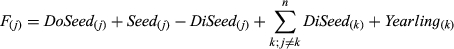

(3)

where *j* is the focal patch and *k* is an index for the vector of patches. Some recently produced seeds (*Seed*) remain in the patch while others (*DiSeed*) disperse and those arriving are added. The amount of seeds that remain and disperse depends on the dispersal kernel.

Dormant seeds were calculated using estimates of probability of seed survival (*s*), probability of reproduction (*φ*<sub>0</sub>), number of reproductive structures (*φ*<sub>1</sub>), fruit set (*φ*<sub>2</sub>), number of viable seeds per fruit (*φ*<sub>3</sub>) and proportion of seeds going dormant (*δ*). This last parameter was multiplied by a per cent to change the contribution of old seeds remaining dormant (*p<sub>1</sub>*) or of new produced seeds becoming dormant (*p<sub>2</sub>*).

Recruitment as new yearlings (seedlings surviving until the annual summer census) included estimates of germination from the seed bank (1 − *δ* × *p<sub>1</sub>*), probability of reproduction (*φ*<sub>0</sub>), number of reproductive structures (*φ*<sub>1</sub>), fruit set (*φ*<sub>2</sub>), number of viable seeds per fruit (*φ*<sub>3</sub>), germination probability (1 − *δ* × *p<sub>2</sub>*) and seedling survival (*φ*<sub>4</sub>).

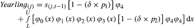

(5)

We compared the predictions of our models to observed absence/presence and abundance in all the 92 studied patches in 2016–2018. Simulations started in 1964, assuming it was at 9 years post-fire and followed patch-specific observed historical burn frequencies, each initiated with a common vector (as in Quintana-Ascencio et al., 2018). The numbers in the initial vector were subjective and were used to obtain relative assessments among patches and models, not absolute estimates. These initial vectors, based on the overall observed height distributions, were consistent with the stable stage distributions of matrices representing an intermediate time-since-fire (9–15 years), corresponding to the time-since-fire when all our simulations started (9 years).

### 2.5 Comparing burn histories

Once we identified the most likely combination of seed dormancy and seed dispersal model parameters, we used them to compare the relative ability to predict observed presence and abundance between projections using the historical fire sequence against 500 ‘null’ models that had the same average fire regime but random ignition years. We used a Weibull function to generate cumulative distributions of probability of ignition. We iteratively searched a combination of parameters such that the chosen distribution had the same mean, and a similar standard error as the observed fire frequency distribution. We started each simulation with the same initial vector, and same initial time-since-fire year (9). For each population independently, and at each step (year) using a uniform random number between 0 and 1 we compared this value against the chosen Weibull model. When the random number was lower than the expected value, a fire occurred and the matrix sequence was modified to simulate the corresponding time-since-fire as in previous models (Quintana-Ascencio et al., 2018).

### 2.6 Analysis

We used generalized linear models to evaluate the association between predicted plant abundance and observed occurrence in the patches and observed abundance of flowering plants. Binomial distributions and logit links were used for presence/absence data and negative binomial distributions and logarithm links for count data. We used Akaike information criterion (AIC; Burnham & Anderson, 2002) to evaluate the predictive ability of models. All analyses and simulations were implemented using the R software package (R Development Core Team, 2018, v2.15.1).

## 3 RESULTS

Seed dormancy and dispersal interacted to affect model projections and their ability to predict observed data (Figure 1). For both presence and abundance, likelihood was higher (lower AIC values) for models with dispersal than with no dispersal. However, within the range of dispersal model likelihood increased as dispersal decreased. The median proportion of seeds in each patch dispersing into the matrix of unsuitable habitat outside of Florida rosemary scrub decreased from 0.987 to 0.829 as the average dispersal decreased. The proportion of seeds lost because their dispersal to unsuitable habitat varied with patch area, being much faster in larger patches (from 0.797 with more dispersal [1 m] to zero seeds lost with less dispersal [0.25 m] respectively in the largest patch) than for smaller patches (from 0.999 to 0.998 lost in the smallest patch). The likelihood of the models also increased with higher dormancy. The change in model likelihood as a function of seed dormancy increased as dispersal decreased (Figure 1).

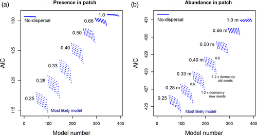

**Figure 1**

Relative likelihood (AIC; smaller most likely) for 392 models of observed (a) patch presence and (b) patch abundance in 2016–2018, both as a function of predicted abundance. Models represent gradients of three factors: dormancy of older seeds (seven levels as proportional change in dormancy: 0.6–1.2, including no change), dormancy of recently produced seeds (same seven levels) and dispersal: eight levels including no-dispersal and mean dispersal = 0.25, 0.28, 0.33, 0.4, 0.5, 0.66 and 1 m). The most likely model (lowest AIC, # 98 in the abscissa; indicated) for both dependent variables had limited dispersal (0.25), and the highest seed dormancy (1.2, 1.2)

Of the 392 demographic models examined (using the historical fire regime), the top model had limited dispersal (dispersal parameter = 4 [0.25 m] and the highest dormancy (new seeds × 1.2 and dormancy of older seeds × 1.2). The projected plant abundances of this model were significantly associated with *H. cumulicola* observed patch presence (Figure 2a; observed presence = 0.72 (*SE* = 0.34) + 0.196 (0.056) × predicted counts; pseudo-*r*<sup>2</sup> = 0.209) and with observed density of flowering plants (Figure 2b; observed counts = 5.08 (0.42) + 0.156 (0.069) × predicted counts; pseudo-*r*<sup>2</sup> = 0.172). Using 0.5 as threshold for patch occurrence probability, this model correctly predicted presence or absence 67% of the time, correctly predicted patch absences 78% of the time (38 of 49) and presences 56% of the time (24 of 43). Predictions were more reliable for large aggregated (mostly occupied) and small isolated patches (mostly non-occupied) (Figure 3). As a comparison, the original demographic model without dispersal and based on the field seed bank estimates (Quintana-Ascencio et al., 2018) correctly predicted only 49% of the time; 53% of the patch absences (26 of 49) and 44% of the presences (19 of 43).

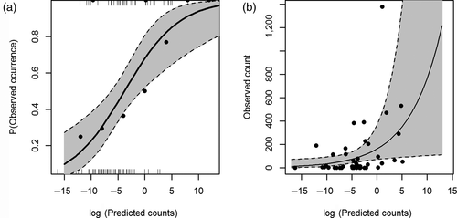

**Figure 2**

(a) Observed occurrences and (b) observed abundances (flowering plants) in 2016–2018 for 92 Florida rosemary scrub patches as a function of predicted densities from the most likely model (dispersal parameter 4 [0.25 m], dormancy of older seeds × 1.2 and dormancy of new seeds × 1.2). Filled black circles in the left plot are observed proportions of the data. Grey fill in both plots indicates 95% CI.

[figure not shown]

**Figure 3**

Maps of the west section of Archbold showing the location of the 92 studied Florida rosemary scrub patches and *Hypericum cumulicola* observed (left) and predicted occupancy (right)

Simulations with the same fire regime but random ignition years produced projections of abundance that were as likely as the historical model explaining patch presence (Figure 4; as indicated by the 95% quantiles of the right inset boxplot). The same random ignition models were similar to the historical burn regime in explaining the observed densities (Figure 4; left inset boxplot). The most notable difference between the simulation with the historical burn regime and the nonhistorical simulations was that the former produced higher estimates of abundance (345,341 plants across all patches vs. 190,376 ± SE = 17,806, *n* = 500 for random fires). The historical simulation had higher burn synchrony among patches (skewness in the number of patches burned by year = 1.79 for the historical and 0.20 + *SE* = 0.01 for the random simulations respectively) and higher densities in 53% of patches than the respective 0.80 quantile, and 73% higher than the 0.50 quantile of the nonhistoric simulations (Figure 4).

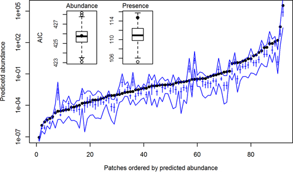

**Figure 4**

Predicted abundance (ordered) for patches from a simulation using the observed burn history (black dots) and for 500 simulations with the random fire regimes (in blue). Blue lines define the polygon inside the 0.01 and the 0.99 quantiles of the predictions with random ignition. In the blue crosses the limits of the vertical lines are the 0.2 and 0.8 quantiles and the horizontal line is at the 0.5 quantile. Most (73%; 67 of 92) of the patches had higher (> 0.5 quantile) predicted densities with the historical (vs. random) regime. However, the model using the historical fires is as likely as the set of models with random ignitions to explain patch occurrence and abundance. Inset there are two boxplots summarizing the AIC of this model set (*n* = 501 simulations) for the models of abundance and presence in relation to random fires and the historical fire regime (the last one emphasized by the two large black dots). Notice that the AIC of the historical model is between the 5 and 95 percentiles of the random ignition models.

## 4 DISCUSSION

We provide evidence of the pivotal role of seed bank, seed dispersal, habitat heterogeneity and historical fire disturbances on plant population dynamics. Difficulties in the collection of these data have limited our understanding of the importance of these processes on population persistence (Caplat, Nathan, & Buckley, 2012). Our study uses long-term and well-replicated demographic data, detailed geographic information and well-documented historical burn information to assess the interaction of these processes on the metapopulation dynamics of *H. cumulicola*, a pyrogenic species restricted to patches of Florida rosemary scrub in central Florida.

Fire frequency significantly affects the persistence of species in pyrogenic environments (Dalgleish & Hartnett, 2008; Emery & Gross, 2005; Kaye, Pendergrass, Finley, & Kauffman, 2001). Different species in the same area adapt to distinct fire frequencies depending on demographic responses. For example, fire frequencies affect the demography of forbs and grasses in tallgrass prairies, but grasses and forbs differ on how fire frequencies alter rates of below-ground bud formation, emergence of vegetative structures and their responses to grazing (Dalgleish & Hartnett, 2008). Fire frequency interacts with fire severity throughout mesic savannas in northern Australia, with frequent fires reducing tree growth rates and increasing fire frequency effects with fire intensity (Murphy, Russell-Smith, & Prior, 2010). Fire can enhance and create suitable habitats for germination and seedling establishment of many species (Keeley & Keeley, 1987; Carrington, 1999), but excessive fire frequencies can deplete populations of plants that depend on seeds for recruitment after fire when they do not allow for recovery of reproductive individuals (Bradstock, Tozer, & Keith, 1997). Furthermore, the post-fire spatial pattern of establishment of species with poor dispersal may depend more on the location and abundance of reproductive plants prior to the fire than on the post-fire microsite conditions (Carrington, 1999). Fire frequency in the Florida scrub can affect the incidence of opportunities for increased recruitment and the length of intervals of seed bank accumulation of *H. cumulicola* (Quintana-Ascencio et al., 2018).

The habitat of *H. cumulicola* experiences spatial and temporal changes in suitability associated with time-since-fire. Large open gaps in recently burned Florida rosemary scrub patches are the most suitable habitat for *H. cumulicola* (Quintana-Ascencio et al., 1998, 2018)*.* Post-fire, increasing shrub cover (Menges, Main, et al., 2017b), decreasing moisture (Weekley, Gagnon, Menges, Quintana-Ascencio, & Saha, 2007), varying nutrients (Schafer & Mack, 2013) and changing interactions with microbes (David et al., 2019) and other organisms (Brudvig & Quintana-Ascencio, 2003) affect the vital rates and population growth of *H. cumulicola*. Dormancy and post-fire germination (Dolan et al., 2008; Quintana-Ascencio & Morales-Hernandez, 1997) increase chances of taking advantage of the occurrence of more suitable recently burned habitats and seed dispersal allows reaching newly created post-fire neighbouring suitable habitats. This combination of attributes can increase chances of persistence in this pyrogenic, heterogeneous and dynamic system.

A large proportion of *H. cumulicola* seeds become dormant and prior models indicated large population growth elasticity for its seed dormancy (Quintana-Ascencio et al., 2003). In the current study, estimates of the most likely model exceeded prior average seed dormancy field estimates. Previous field estimates of seed dormancy and germination varied considerably across time-since-fire (Quintana-Ascencio et al., 1998). Better field sampling including a larger representation of the time-since-fire gradient combined with the incorporation of the variation of these rates in models are features that can be explored to improve future estimates of seed dormancy and its demographic effects.

Recent theoretical work suggests that positive spatial and temporal habitat correlations can affect seed dormancy and dispersal distance (Snyder, 2006). In the Florida scrub, fire and topography can be responsible for positive correlations among habitat patches. Fire often simultaneously burns groups of patches synchronizing time-since-fire, fire severity and other aspects their fire regimes. Neighbouring patches also frequently share similar soils and elevation. Our data indicate that, in this system, limited seed dispersal and high dormancy can co-occur. These results are consistent with Snyder (2006) predictions that scenarios with positive habitat temporal correlations can allow the concurrent occurrence of persistent seed banks and seed dispersal among patches.

We used the smallest grid cells consistent with other spatial data available (5 x 5 m). However, considering the range of the mean distances evaluated (0.25 – 1 m), we probably under-estimated seed spread among cells. This limitation was partially compensated by the integration of these estimates across multiple cells within patches. Because of these reasons we interpret our results as indicators of limited dispersal in the range evaluated for *H. cumulicola,* instead of attributing any specific distance for the mean dispersal of this species. In this study, we were interested in the role of dispersal among patches and landscape structure on population variation and assumed homogeneous environmental conditions with the patches. We recognize that microhabitat heterogeneity and the consequences of short distance dispersal on demography are important (Bialic-Murphy, Gaoue, & Kawelo, 2017; Godínez-Alvarez & Jordano, 2007; Loayza & Knight, 2010), but the analysis of these factors on our focal species is beyond the scope of this work.

The role of the interval of fire regimes for the persistence of *H. cumulicola* in Florida scrub has been previously recognized (Quintana-Ascencio et al., 2018, 2003). Here, we emphasize the importance of fire history. The conditions resulting of the actual fire history produced different projections compared with simulation scenarios with the same average fire frequency but nonhistorical random ignitions. This may reflect, in part, increasing frequencies of fire in Florida rosemary scrub in recent decades (Menges, Crate, et al., 2017a), which would favour *H. cumulicola.* In addition, the observed synchrony of fires among neighbouring patches is a likely explanation of the higher densities predicted by the simulations with the historical (vs. random) fire regime. The arrival of seeds from multiple neighbouring patches experiencing synchronous favourable conditions after local fires will likely boost population growth in these patches. The magnitude of these effects is probably exacerbated since most demographic models, including ours, are simulated as Monte Carlo process with no regard for prior stage conditions (but see Ehrlén, 2000, Menges & Quintana-Ascencio, 2004).

Demographic studies considering the effects of dispersal and spatial and temporal habitat heterogeneity are scarce (Crone et al., 2013). Since most plant demographic studies have only considered few populations monitored for 2–3 years (Menges, 2000; Salguero-Gómez et al., 2015) and often without regard to the potential drivers of the demographic variation (Ehrlén & Morris, 2015), the critical effects of variables affecting regional dynamics are poorly understood. Furthermore, relevant rates, such as seed dormancy and dispersal, are particularly difficult to estimate (Thompson & Grime, 1979). Available evidence suggests that landscape dynamics are common among plants, but most models for large-scale population dynamics have concentrated on animals (Eriksson, 1996). Models including seed banks, dispersal and habitat heterogeneity can significantly improve the quality of plant population forecasts and management recommendations. In our study, the inclusion of variables at the landscape level and the evaluation of various rates of seed dormancy and seed dispersal allowed us to substantially improve the ability of our models to correctly project observed occurrence and presence of *H. cumulicola*. Similarly, despite substantial uncertainty on demographic and dispersal parameters, a stage-structured model simulating *Pinus nigra* spread into ungrazed grasslands in New Zealand provided robust recommendations (Buckley et al., 2005).

Wise biodiversity conservation and management will depend of understanding of population variation at several scales. At the landscape scale, decisions on prescribed fires (or other disturbances) will benefit from our knowledge of the consequences of fire frequency, but also of the location of ignitions and the probability of fire spread. Because of the prevalence of metapopulation dynamics, we should also be aware of the significance of changes in the availability and configuration of suitable habitat associated with human or non-human landscape changes. Therefore, we are convinced that studies of regional population dynamics will provide useful information to address current pressing environmental issues.

## ACKNOWLEDGEMENTS

We thank many Archbold research assistants and interns and UCF students who helped to collect and organize these data. R. Lavoy, M. Morales-Hernández, A. Z. Quintana-Morales, E. M. Quintana-Morales, Stacy A. Smith and C. W. Weekley provided extraordinary support. This work was partially funded by NSF-DEB 1347247 and NSF-DEB 0812753. Computer simulations were facilitated by Patrick Larabee and the staff of the UCF Advanced Research Computing Center (Stokes).

## AUTHORS’ CONTRIBUTIONS

P.F.Q.-A. and E.S.M. designed this study and collaborated with S.M.K. organizing and implementing field work and curating the data. V.L.S. gathered and prepared the GIS data and produced the maps. P.F.Q.-A., B.O. and F.L.B. developed the model. F.L.B. and H.L. performed the simulations. P.F.Q.-A. and E.S.M. wrote the initial version of the manuscript and all the authors edited the manuscript.

## Citing Literature

[figure not shown]

November 2019

Pages 2760-2771

Citation Statements

beta

- Supporting

  Supporting0
- Mentioning

  Mentioning4
- Contrasting

  Contrasting0

powered by

[figure not shown]

  [Journal of Ecology](https://besjournals.onlinelibrary.wiley.com/journal/13652745)
- [The influence of fire on the demography of a dominant grass species of West African savannas, *Hyparrhenia diplandra*](https://besjournals.onlinelibrary.wiley.com/doi/full/10.1046/j.1365-2745.2001.00532.x)

  [Lisa K. M. Garnier](https://besjournals.onlinelibrary.wiley.com/action/doSearch?ContribAuthorRaw=Garnier%2C+Lisa+K+M), [Isabelle Dajoz](https://besjournals.onlinelibrary.wiley.com/action/doSearch?ContribAuthorRaw=Dajoz%2C+Isabelle),

  [DREW W. PURVES](https://besjournals.onlinelibrary.wiley.com/action/doSearch?ContribAuthorRaw=PURVES%2C+DREW+W), [JONATHAN DUSHOFF](https://besjournals.onlinelibrary.wiley.com/action/doSearch?ContribAuthorRaw=DUSHOFF%2C+JONATHAN),

  [Journal of Ecology](https://besjournals.onlinelibrary.wiley.com/journal/13652745)
- [Droughts and the ecological future of tropical savanna vegetation](https://besjournals.onlinelibrary.wiley.com/doi/full/10.1111/1365-2745.13195)

  [Mahesh Sankaran](https://besjournals.onlinelibrary.wiley.com/action/doSearch?ContribAuthorRaw=Sankaran%2C+Mahesh),

  [Journal of Ecology](https://besjournals.onlinelibrary.wiley.com/journal/13652745)